# Progress Memo 2

Final Project  
Data Science 1 with R (STAT 301-1)

Author

Elizabeth Son

Published

December 3, 2023

**Github Repo Link**

https://github.com/stat301-1-2023-fall/final-project-1-elizabethson

## Introduction

I joined a dataset called “GDP Over Hours Worked”[^1] with 5 datasets on happiness from “The World Happiness Report”[^2] by adding a variable called `year` to each happiness data set using a function. Using the primary keys `country` and `year`, I combined the GDP and happiness datasets into one dataset called `gdp_happiness`. Some countries changed names over time, so I manually updated some `country` names using the mutate function. Finally, I changed `region` to a factor for further data explorations.

## Relevant Correlations

The initial step in my data exploration is to examine which variables in my dataset have relationships worth exploring. In Figure 1, a correlation plot reveals that variables including `gdp_ppp_over_labor_force` (GDP for each person in the labor force) and `employment_rate` (employment rate) have a strong correlation with `happiness_score` (happiness score).

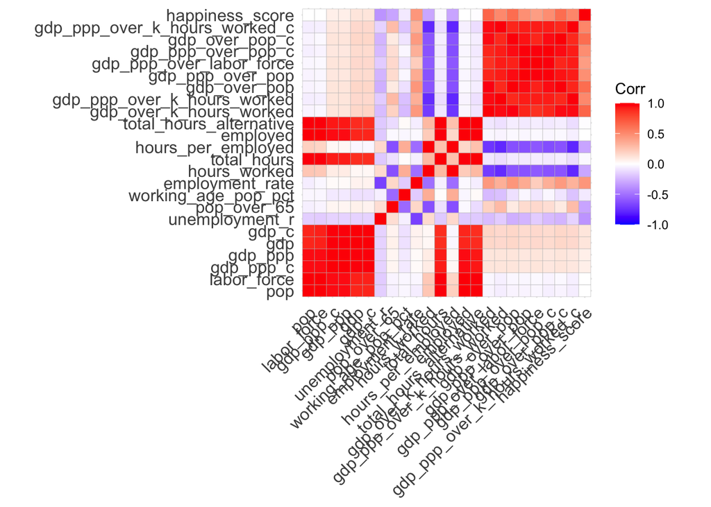

Figure 1: Correlation plot of GDP variables and happiness score

## Further Examining Relevant Correlations

With the information given by Figure 1, I visualized the relationship between `happiness_score` and 3 variables from the GDP dataset using scatterplots. These demonstrate a clearer relationship between happiness and the independent variable.

### Happiness Score vs. GDP per Person Over Labor Force

Figure 2 shows a scatterplot of happiness score vs. GDP per person in the labor force. The plot shows a clear, positive relationship but the linear model does not seem to provide the best fit for this relationship. Instead, a log function might better fit the data. Additionally, there appear to be some observations with `gdp_ppp_over_labor_force` far from the others. These are worth exploring further.

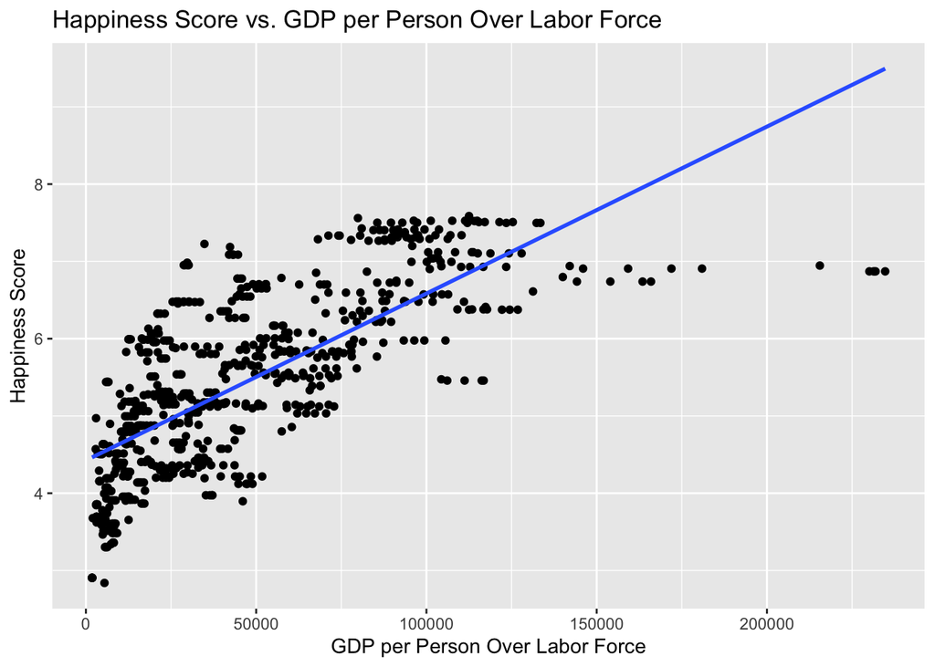

Figure 2: Scatter plot of happiness score vs. GDP per person over labor force

### Happiness Score vs. Employment Rate

Figure 3 shows a scatterplot of happiness score vs. employment rate. The plot shows positive relationship between the variables: as employment rate increases, happiness score also increases.

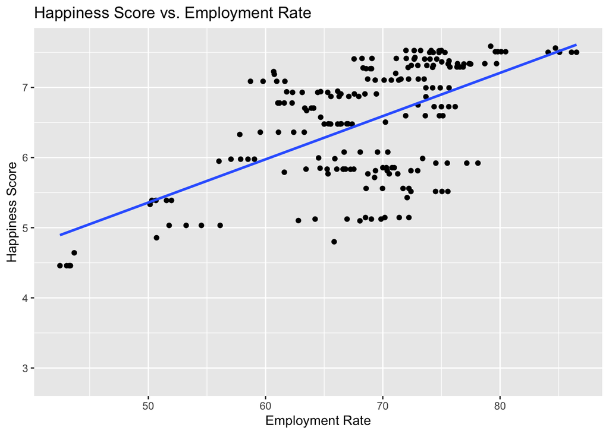

Figure 3: Scatter plot of happiness score vs. employment rate

### Happiness Score vs. Hours Worked per Employed Person

Figure 4 shows a scatterplot of happiness score vs. hours worked per employed person. I expected a strong, negative linear relationship between these variables, but the negative relationship between happiness score and hours worked per employed person is weak.

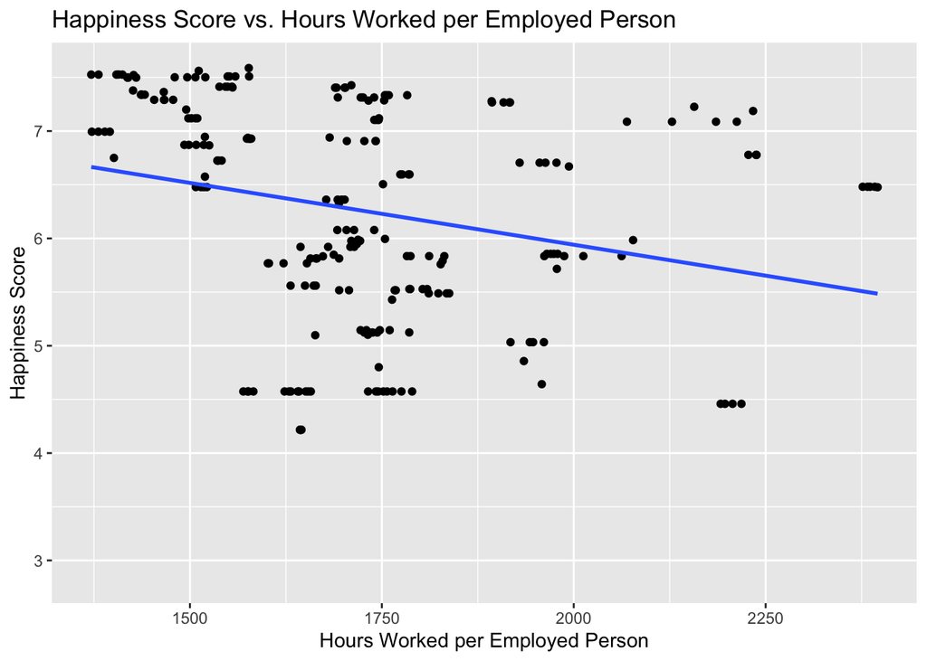

Figure 4: Scatter plot of happiness score vs. hours worked per employed person

## Density per Region

The scatterplots revealed that relationships that I believed would be strong existed, but were not as strong as I had believed. In addition, they revealed outliers that may skew the lines of best fit in adverse ways. Thus, faceting by the variable `region` may give further insight into certain relationships on productivity, GDP, and happiness. Figure 5 shows the counts of observations in the 10 different regions that are represented in the dataset. This shows that further explorations can factor in region, because factoring by `country` was not possible with such few observations per level.

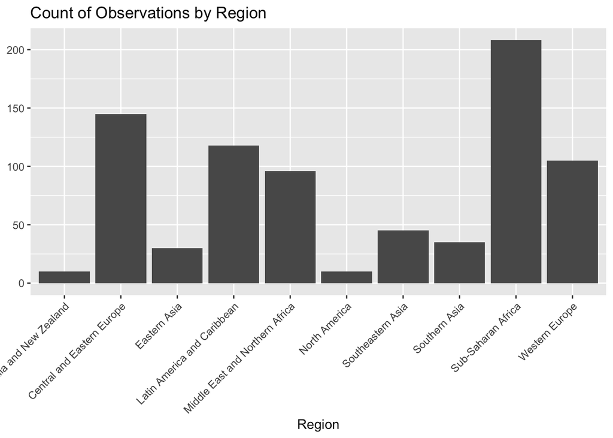

Figure 5: Density per region

## Happiness Score vs. Hours Worked per Employed Person by Region

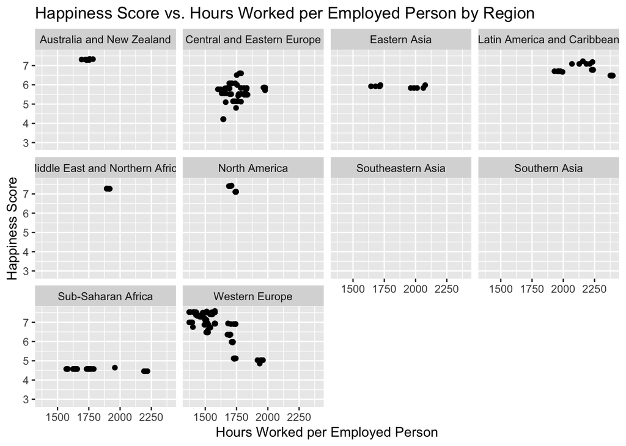

Figure 6: Happiness score vs. hours worked per employed person by region

## Conclusion

My exploration started with some data cleaning to get a dataset that I could work with. Then, I created a correlation plot to determine which relationships would be worth exploring. Scatterplots of relevant relationships further revealed that relationships that I expected to be strong were not. Finally, I factored by region to explore certain relationships further in the data exploration process.

My findings reveal that there are positive relationships between happiness score and GDP per person in the labor force and happiness score and employment rate. There is a negative relationship between happiness score and hours worked per employed person. However, this relationship only seems to be negative for countries in the Western European region.

### Next Steps

Some potential next steps include fitting my scatterplots with lines that are not just linear and faceting more relationships by region.

I also want to look at more relationships between happiness score and other variables from the GDP dataset and including other relevant variables from the happiness dataset, such as `generosity`. However, I am unsure how to include these variables without cluttering my report with too much information without a concise goal. My exploration aims to find the balance between measures of happiness and productivity, so I need to determine exactly how to quantify productivity.

Finally, I hope to map time trends (from 2015-2019) by region to see if there are any regions seeing “improvements” in various metrics over time.

## References

The Economist (2023). GDP Over Hours Worked, https://github.com/TheEconomist/the-economist-gdp-per-hour-estimates/blob/main/output-data/gdp_over_hours_worked.csv

Kaggle (2019). World Happiness Report, https://www.kaggle.com/datasets/unsdsn/world-happiness

## Footnotes

[^1]: https://github.com/TheEconomist/the-economist-gdp-per-hour-estimates/blob/main/output-data/gdp_over_hours_worked.csv
[^2]: https://www.kaggle.com/datasets/unsdsn/world-happiness